# Personality skills

Soft skills, personality skills, SEB skills, life skills e altri mostri

Author

Tommaso Feraco

# **Soft (personality) skills: definizione, tipologie e modelli teorici**

Le soft skill, spesso chiamate competenze trasversali o non tecniche, rappresentano un insieme variegato di abilità personali che possono differire in base alle definizioni, ai contesti di applicazione e ai modelli teorici utilizzati per analizzarle.

In questo capitolo cercheremo di fare un po’ di chiarezza focalizzando l’attenzione sui modelli più recenti elaborati in psicologia della personalità.

## Definizioni

### Una prima approssimazione

Negli ultimi anni, l’interesse per le caratteristiche individuali che favoriscono il successo nella vita quotidiana, negli studi e nella carriera è cresciuto notevolmente<sup>1–3</sup>. Queste caratteristiche sono state descritte con termini diversi<sup>4,5</sup>: “competenze non cognitive” per distinguerle dalle abilità mentali più tradizionali come l’intelligenza; “soft skill” per differenziarle dalle “hard skills”, ossia competenze tecniche necessarie per svolgere mansioni specifiche, come la programmazione informatica<sup>2</sup>; “punti di forza del carattere” per evidenziarne il valore positivo a livello sociale<sup>6</sup>; o ancora “competenze del XXI secolo”, espressione che richiama l’importanza di queste abilità in un mercato del lavoro moderno e in continua trasformazione.

Ogni termine propone un taglio e una visione particolare delle competenze trasversali. Ad esempio, nei contesti lavorativi l’accento è posto sulla capacità di adattarsi ai cambiamenti e alle nuove esigenze professionali e troviamo skill come la creatività, la flessibilità e l’apprendimento permanente (*life-long learning*), elementi chiave per sostenere l’innovazione tecnologica e il benessere personale. In ambito educativo, invece, ci si concentra su competenze che influenzano il rendimento accademico e il benessere emotivo, come la gestione delle emozioni, il pensiero critico e la risoluzione dei problemi. Insomma, la selezione e categorizzazione delle skill dipende molto dal motivo per cui si decide di analizzarle.

Nonostante le differenze terminologiche e metodologiche, le soft skill nei diversi contesti condividono alcune caratteristiche fondamentali. In primo luogo, vengono generalmente definite come abilità non tecniche che riflettono aspetti della personalità (*e già vediamo che qualcosa non quadra*), del comportamento sociale e della capacità di costruire relazioni efficaci<sup>7</sup>. In secondo luogo, sono considerate competenze sviluppabili attraverso esperienze quotidiane, attività extrascolastiche e hobby come lo sport o la musica<sup>8–10</sup>. Infine, le soft skill sono per definizione trasferibili: una volta acquisite, possono essere applicate in diversi contesti per rispondere a una varietà di sfide e richieste<sup>11</sup>.

Un esempio pratico è rappresentato dalla capacità di lavorare in squadra, che può essere sviluppata attraverso attività sportive e risultare poi cruciale durante lo studio, l’università o la carriera professionale. Al contrario, una competenza tecnica specifica (*hard*), come la programmazione informatica, potrebbe facilitare l’inserimento in un determinato ruolo lavorativo ma non trovare applicazione in situazioni familiari o sociali.

In sintesi, le soft skill possono essere definite come quelle qualità individuali che migliorano la capacità di adattarsi agli altri, affrontare le sfide e rispondere in modo efficace alle richieste dell’ambiente circostante<sup>12</sup>, facilitando così il raggiungimento del successo personale in molteplici ambiti.

Ma cosa può differenziare le soft skill da un tratto di personalità, se così definite? Ricordando che i tratti di personalità definiscono come una persona risponde -tendenzialmente- agli stimoli ambientali a livello comportamentale, emotivo e di pensiero, praticamente non cambia niente<sup>3</sup> tranne il fatto che la skill sottolinea un estremo del tratto -quello di solito ritenuto più funzionale- e non il tratto nella sua interezza. Ad esempio, essere molto coscienziosi è bene in quanto ci porta al successo<sup>13</sup>, mentre esserlo poco significa essere generalmente disorganizzati e inaffidabili, quindi male, quindi non skill. Ma saremmo d’accordo col dire che le persone introverse sono peggio di quelle estroverse solo perchè parlare in pubblico è utile in ambito lavorativo? Spero di no…

Può quindi bastare questa definizione? Sarete d’accordo con me che no, non basta.

### Social, emotional, and behavioral skills. Una nuova prospettiva

Passiamo quindi alle più recenti definizioni di soft skill da un punto di vista integrativo e fortemente psicologico.

Soto e colleghi<sup>3</sup>, famosi e influenti psicologi della personalità, definiscono le competenze sociali, emotive e comportamentali (Social, Emotional e Behavioral, SEB, dall’inglese) come un insieme di abilità funzionali che consentono agli individui di instaurare e mantenere relazioni positive, regolare le proprie emozioni e gestire comportamenti finalizzati al raggiungimento di obiettivi personali e di apprendimento.

Dall’analisi delle molteplici tassonomie esistenti sulle soft skill (oltre cento, vedi: http://exploresel.gse.harvard.edu/), hanno elaborato un quadro teorico ampio e integrato, rilevando che molte competenze risultano condivise tra diversi modelli concettuali (ad esempio, l’adattabilità può essere indicata anche come flessibilità o elasticità a seconda del contesto). Hanno poi cercato di distinguere queste skill dai tratti di personalità. Infatti, un aspetto centrale del loro lavoro è la netta distinzione tra le abilità pratiche, ossia le *skill* vere e proprie, e le inclinazioni o preferenze comportamentali di base, cioè i tratti di personalità. Da un lato, infatti, troviamo le predisposizioni individuali che tendono a stabilire come una persona si comporterà in circostanze diverse (pensiamo a una persona timida, il cui comportamento risulta generalmente coerente in vari contesti); dall’altro, abbiamo le abilità che l’individuo può esprimere quando la situazione lo richiede. Ad esempio, uno studente può essere chiamato a sostenere un esame orale o a presentare un lavoro di gruppo: è in queste situazioni che entrano in gioco le competenze SEB, ovvero ciò che l’individuo *sa fare* o può apprendere per rispondere alle richieste del contesto.

Le competenze SEB (o soft skills) possono essere considerate come una “cassetta degli attrezzi” a disposizione della persona, strumenti che possono essere utilizzati o sviluppati con l’esperienza e la pratica, senza modificare o corrispondere necessariamente alle preferenze comportamentali di base<sup>14</sup>. Prendiamo ad esempio un individuo che tende a preferire l’isolamento e a non cercare interazioni sociali. In situazioni specifiche, come una presentazione in pubblico o un lavoro di gruppo, questa persona dovrà superare la propria inclinazione naturale e applicare abilità come il *public speaking* (gestione della voce, della postura e della mimica) per rispondere in modo efficace alla richiesta. Lo stesso principio vale al contrario: una persona molto socievole potrebbe dover contenere impulsi e mantenere l’autocontrollo in contesti più strutturati, come durante una lezione frontale.

In sintesi, le competenze SEB (e le soft skill più in generale) sono abilità flessibili che possono essere apprese e perfezionate, indipendentemente dalle disposizioni personali innate. Questo le rende estremamente utili per affrontare situazioni complesse o sfide specifiche.

#### I cinque domini delle competenze SEB

Entrando nel dettaglio, Soto e colleghi<sup>3</sup> hanno proposto una classificazione teorica delle soft skill, raggruppandole in cinque macrodomini principali, all’interno dei quali sono incluse 32 competenze specifiche (si veda Figure 1). Ogni cerchio nella figura rappresenta un dominio, che raggruppa competenze affini per scopi funzionali: alcune risultano più rilevanti in ambito sociale (come le capacità di interazione), mentre altre sono cruciali per compiti creativi (come le capacità di innovazione) e altre per il raggiungimento di compiti a lungo termine (come le capacità di autogestione). I cinque macrodomini sono:

- **Capacità di interazione**: includono le abilità necessarie per interagire attivamente con altre persone, come la leadership e la persuasione.
- **Capacità di cooperazione**: si riferiscono alle abilità utili per costruire e mantenere relazioni sociali positive, come la collaborazione e l’empatia.
- **Capacità di autogestione**: riguardano le competenze necessarie per organizzarsi, prendere decisioni e perseguire obiettivi, come la costanza, la gestione del tempo e il decision-making.
- **Capacità di regolazione emotiva**: si riferiscono alle abilità necessarie a controllare emozioni e stati d’animo, come la gestione dello stress e l’ottimismo.
- **Capacità di innovazione**: includono competenze utili per affrontare esperienze e idee nuove, come la creatività e l’interculturalità.

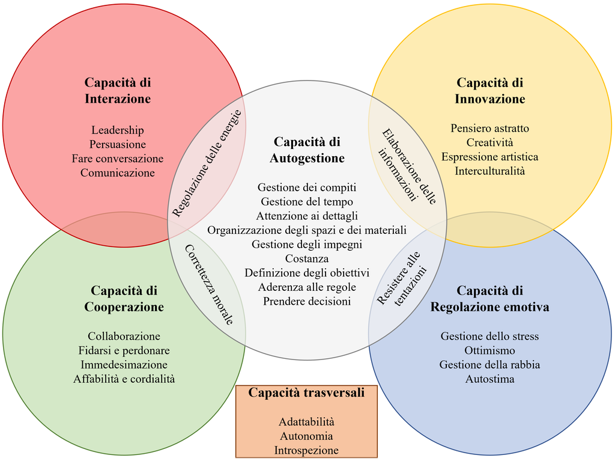

Figure 1: Rappresentazione del modello SEB

##### Competenze interstiziali e trasversali

Nella classificazione proposta, la maggior parte delle competenze SEB è attribuita a uno dei cinque domini. Tuttavia, quattro competenze, dette *interstiziali*, condividono caratteristiche di più domini, con l’autogestione come elemento comune. Ad esempio, la *resistenza alle tentazioni* rientra sia nelle competenze di regolazione emotiva (per gestire la frustrazione derivante da una gratificazione immediata mancata) sia nell’autogestione (per inibire impulsi e mantenere la concentrazione su obiettivi a lungo termine). Pensiamo a uno studente che, pur stanco o distratto da un invito degli amici, decide di completare il proprio piano di studio prima di concedersi una pausa.

Infine, esistono tre competenze definite *trasversali*, in quanto non riconducibili a un dominio specifico: l’adattabilità, l’autonomia e l’introspezione. Queste abilità sono più generali e applicabili in contesti molto diversi.

Nonostante questa organizzazione in domini e categorie, ogni singola abilità mantiene la propria unicità e specificità. Pertanto, in interventi educativi, programmi di ricerca o lezioni, si può scegliere se focalizzarsi su macrogruppi di competenze o approfondire singole abilità.

Per ulteriori dettagli sulle 32 competenze SEB, si rimanda al sito ufficiale: http://www.sebskills.com.

In conclusione, le soft skill rappresentano un insieme di qualità individuali che permettono alle persone di adattarsi efficacemente agli altri, affrontare con successo le sfide e rispondere in modo proattivo alle richieste dell’ambiente circostante, contribuendo così a favorire il successo personale in contesti diversi. Queste però non corrispondono a come la persona tende a comportarsi di solito, anche se ci assomigliano molto.

#### Similitudini tra tratti e skill

Come forse avrete già notato, individuiamo 5 macrodomini di competenze. Proprio cinque. Proprio come i Big Five. Coincidenze? Io non credo.

La corrispondenza è infatti ovvia e insita nel modello di riferimento (si veda Table 1). Soto e colleghi raggruppano volontariamente le skill sulla base dei Big Five. Se ci pensiamo bene, infatti, i Big Five dovrebbero rappresentare e categorizzare, nel modo più generale possibile, il maggior numero di comportamenti che una persona può mettere in atto. Ad ogni comportamento, come ad esempio parlare con gli altri (estroversione), può però essere associata anche una corrispettiva abilità, come **saper** parlare con gli altri in modo efficace (interazione sociale). Usare il Big Five è quindi un ottimo modo per individuare e categorizzare anche le skill possibili.

Table 1: Corrispondenza tra skill e tratti

| Tratto | Skill |
| --- | --- |
| Apertura mentale | Abilità di innovazione |
| Coscienziosità | Abilità di autogestione |
| Estroversione | Abilità di interazione sociale |
| Amicalità | Abilità di cooperazione |
| Stabilità emotiva | Abilità di regolazione emotiva |

Oltre che teoricamente, le due caratteristiche vanno anche a braccetto nella stessa persona. Se infatti pensiamo a una persona che gioca a calcio tutti i giorni, ci immaginiamo che sia anche brava a farlo. Allo stesso modo, una persona molto estroversa, che parla con tutti, sta al centro dell’attenzione e ama le situazioni socialmente stimolanti, imparerà, piano piano, ad attuare questi comportamenti in modo ottimale. Viceversa, una persona molto brava a giocare a calcio, per talento o fortuna, probabilmente giocherà spesso e volentieri a calcio. Così una persona molto brava a regolare le proprie emozioni quando vuole, tenderà a farlo spesso, risultando più stabile emotivamente (meno nevrotica). Lo stesso esempio può essere fatto per ogni skill e ogni tratto. Provaci, magari ti verrà chiesto all’esame.

Ricordiamo però che, nonostante le due cose siano molto correlate (si veda Figure 2), tratti e skill possono anche non corrispondere all’interno della stessa persona. Abbiamo quindi persone molto introverse, a cui non piace mettersi al centro dell’attenzione e che raramente iniziano loro sponte a parlare con degli sconosciuti, ma che sono comunque molto brave a parlare in pubblico, se necessario. Certo, probabilmente non si offriranno volontarie per farlo in un lavoro di gruppo, ma se dovessero, se la caverebbero comunque molto bene.

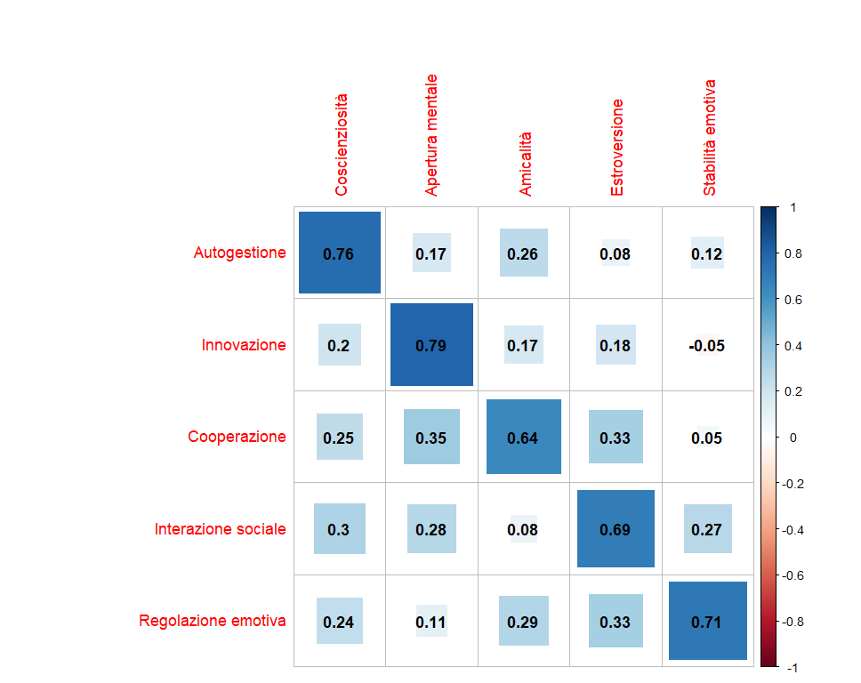

Figure 2: Correlazione tra skill e tratti

Come si vede dall’immagine ( Figure 2), le correlazioni tra i tratti corrispondenti sono molto alte a indicare che, con gli attuali metodi di misurazione, facciamo fatica a distinguere tra una e l’altra. Nonostante questo, però, sappiamo che una correlazione non perfetta prevede comunque che ci siano persone con punteggi molto alti in una variabile ma bassi o medi nell’altra (si veda Figure 3).

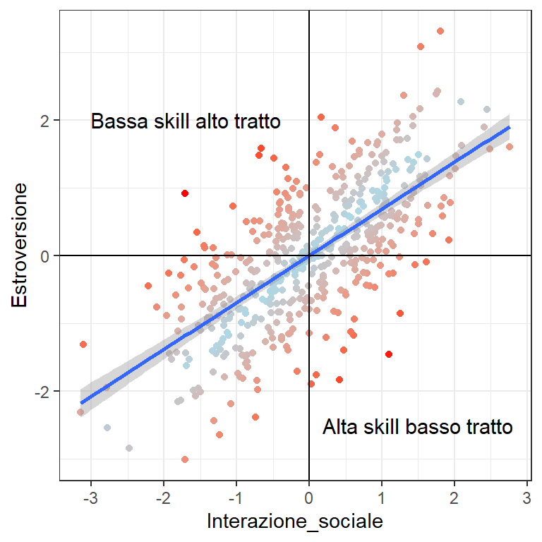

Figure 3: Individui (in rosso) con differenti punteggi di skill e tratto data una correlazione di .69

Un primo studio che ha indagato cosa comporta avere caratteristiche di personalità e di skill differenti<sup>14</sup> ci mostra come persone con alto tratto, ad esempio molto estroverse, ma bassa skill, quindi poco brave in interazione sociale, riportano, tra gli altri, punteggi di benessere e soddisfazione di vita più bassi. Immagina, tornando all’esempio del calcio, di giocare tutti i giorni ma essere comunque scarso. Come ti sentiresti? Il contrario invece, quindi alta skill con basso tratto, non sembra invece influire negativamente sul benessere della persona. Può infatti essere bello avere una buona abilità in qualcosa anche se non lo si fa spesso…male non fa.

#### Concludendo

Queste cinque dimensioni delineano un insieme di abilità che consentono di adattare e modulare il comportamento in risposta alle esigenze contestuali, anche quando l’individuo non possiede una naturale inclinazione o predisposizione a comportarsi in quel modo. Mentre la preferenza (il tratto) indica l’approccio spontaneo con cui una persona tenderebbe ad affrontare un compito, la competenza SEB rappresenta l’abilità concreta di agire, pensare e interagire in modo funzionale per rispondere a una specifica richiesta. Questo concetto evidenzia la natura flessibile e adattabile del comportamento umano e sottolinea come le competenze SEB siano abilità dinamiche, modificabili e sviluppabili con il tempo che una persona può utilizzare quando vuole o ha bisogno di farlo.

## Misurare le soft skills

Misurare le SEB skills non è cosa facile, infatti, nel panorama della letteratura scientifica, non esiste ancora un consenso uniforme sulle modalità di valutazione delle soft skills nonostante siano stati proposti vari approcci metodologici<sup>15</sup>. Abrahams e colleghi<sup>4</sup> hanno esaminato la complessità della valutazione di queste competenze, identificando diverse metodologie utilizzate in questo campo, tra cui i questionari self-report (in cui gli individui valutano quanto certi comportamenti descrivano la loro condotta abituale), l’ambulatory assessment (che richiede agli individui di registrare frequentemente durante la giornata i propri pensieri, emozioni e comportamenti), i test situazionali (che propongono scenari ipotetici per cui le persone devono scegliere l’opzione che meglio rappresenta il loro comportamento tipico) e le misure comportamentali o di performance (che rilevano competenze specifiche come la creatività o l’abilità di riconoscere emozioni). Un possibile compromesso tra questi approcci potrebbe essere rappresentato dagli inventari di competenze, ovvero questionari self-report nei quali i partecipanti valutano la loro capacità di eseguire determinati comportamenti in base alla situazione.

Un esempio recente di questi inventari, con buone proprietà psicometriche, è il BESSI (Behavioral, Emotional, and Social Skills Inventory)<sup>16</sup>, che si basa sul nuovo modello delle SEB skills. Il BESSI ha dimostrato validità sia nella versione originale che nelle sue versioni tedesca<sup>17</sup>, spagnola<sup>18</sup> e italiana<sup>19</sup> (disponibile liberamente al link https://doi.org/10.17605/OSF.IO/VYZPN). Tuttavia, pur essendo un strumento rigoroso e ampiamente riconosciuto in ambito accademico, l’applicabilità del BESSI è limitata a contesti dove l’uso di metodologie self-report non presenta problematiche, come ad esempio nella selezione del personale, dove c’è il rischio che i partecipanti alterino le proprie risposte a fini personali. In tali circostanze, potrebbero essere necessari metodi alternativi di valutazione, come prove oggettive di creatività, problem solving o pensiero critico, o l’adozione di modalità miste (ovvero combinare misurazioni soggettive e oggettive). Tuttavia, tali prove non sono disponibili per tutte le soft skills, come l’iniziativa, la curiosità o la perseveranza. Pertanto, in ogni caso, sarà necessario scegliere l’approccio più adatto in base al contesto e agli obiettivi specifici della valutazione.

Ma cosa distingue il BESSI dal Big Five Inventory? La principale differenza, oltre agli item che sono ovviamente diversi, risiede nel tipo di domanda che viene posta e alla modalità di risposta (si veda Table 2). Infatti, osservando i questionari che indagano i tratti di personalità viene solitamente chiesto di valutare quanto spesso viene svolta una certa azione o provata una certa emozione (es. “*non mi capita spesso di sentirmi teso*”). Nel BESSI viene invece richiesto di valutare quanto si è bravi a svolgere determinate azioni come “*calmarti quando ti senti in ansia*” (1 = per niente bene; 5 = estremamente bene).

Table 2: Item di tratto vs item di skill

| Tratto/skill | Item di tratto (*mi vedo come una persona che..*) | Item di skill (*Quanto bene sai…*) |
| --- | --- | --- |
| Estroversione/interazione sociale | *È socievole, chiacchierona* | *Iniziare una conversazione* |
| Stabilità emotiva/regolazione emotiva | *Raramente si sente in ansia* | *Calmarsi quando si sente in ansia* |
| Coscienziosità/autogestione | *Persiste finchè non ha completato i compiti* | *Continuare a lavorare finchè il compito non è finito* |
| Amicalità/cooperazione | *Aiuta gli altri* | *Capire come si sentono le persone* |
| Apertura mentale/innovazione | *È curiosa di molte cose diverse* | *Trovare nuove idee* |

Nonostante questa distinzione sembri ovvia, fino a pochi anni fa venivano utilizzate formulazioni di item identiche agli item di tratto per misurare le skill. Addirittura in alcuni (molti!) casi vengono utilizzati direttamente gli item del Big Five, ma parlando di skill<sup>ad esempio 2</sup>. Per fortuna voi non farete mai questo errore!

## Il cambiamento delle soft skills

Una delle principali ipotesi riguardo le soft skills è che queste mutino nel tempo e che cambino più facilmente rispetto a costrutti più stabili come i tratti di personalità<sup>8,20,21</sup>. Ma è davvero così? Sfortunatamente ne sappiamo ancora poco e le prime ricerche basate sul modello SEB stanno ancora venendo condotte, ma alcuni primi risultati sembrano promettenti.

Sappiamo, ad esempio, che durante l’adolescenza queste cambiano molto, con cadute e picchi che variano in base al genere/sesso dei partecipanti e alla loro età<sup>8,22</sup>. Dalla Figure 4 possiamo infatti notare come maschi e femmine mostrino livelli diversi di abilità di interazione sociale e regolazione emotiva (a favore dei maschi) e di innovazione e cooperazione (a favore delle femmine). Tali differenze però non sono stabili nel tempo.

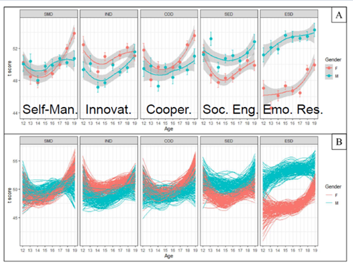

Figure 4: Andamento delle SEB skills durante l’adolescenza

Dalla Figure 5 possiamo notare un ulteriore spunto interessante. Ricordandoci che la varianza non è altro che il quadrato delle differenze rispetto alla media, l’immagine ci mostra valori generalmente più alti e statisticamente significativi per quanto riguarda le skill rispetto a quanto succeda per i tratti. In altre parole, se misurassimo con due questionari skill e tratti a tempo zero e poi di nuovo dopo quattro mesi e nuovamente dopo otto mesi, vedremmo molte più variazioni nelle skill rispetto a quante ne osserveremmo nei tratti, a conferma dell’ipotesi della (maggiore) stabilità dei tratti e della (maggiore) malleabilità delle skill.

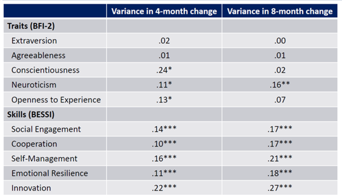

Figure 5: Variazione spontanea di skill e tratti nel tempo

### Volitional change goals

Vi è poi un ulteriore punto di interesse su cui riflettere: le persone si ritengono soddisfatte delle proprie skill e dei propri tratti o vorrebbero cambiarli? Perchè? Cosa pensano di tali cambiamenti? Li vedono come fattibili o meno?

Questi temi in psicologia della personalità sono molto studiati<sup>23,24</sup> e ci suggeriscono che quasi la totalità delle persone desidera cambiare almeno uno, se non quasi tutti i propri tratti di personalità (almeno un poco). Ma questo è ancor più vero per quanto riguarda le skill.

Infatti, da una semplice manipolazione sperimentale emerge come le persone riportano un maggior desiderio di cambiare alcune delle loro skill rispetto ai corrispettivi tratti. Dalla Figure 6 possiamo infatti notare come le persone riportino una preferenza più spiccata verso il cambiamento delle skill di autogestione (SMD) e interazione sociale (SED) rispetto alla coscienziosità e all’estroversione.

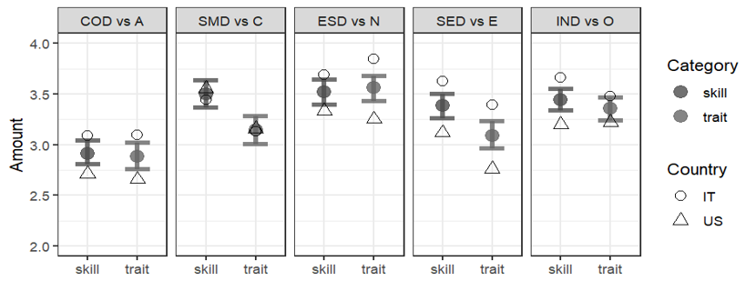

Figure 6: Obiettivi di cambiamento di skill e tratti

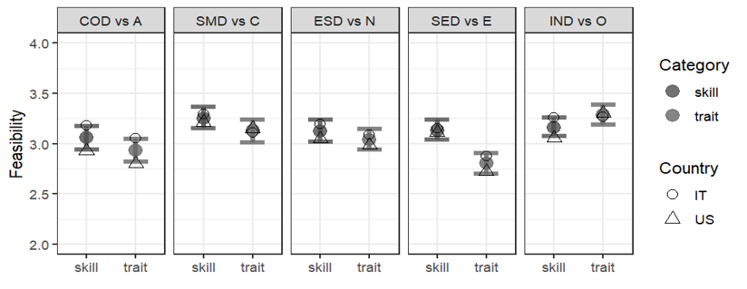

Figure 7: Fattibilità del cambiamento

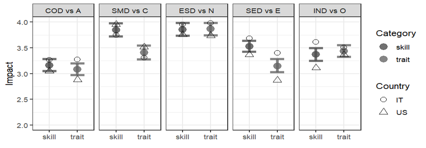

Figure 8: Impatto del cambiamento

Questi risultati possono suggerirci come, da psicologi interessati a promuovere uno sviluppo funzionale dell’individuo, possa essere vincente proporre interventi e training per il miglioramento delle skill, in quanto più desiderabile, ma anche perchè le persone ritengono tale cambiamento fattibile e di impatto; fattori fondamentali per sviluppare un training partecipato e motivante, nonchè di successo<sup>25</sup>.

## Impatto delle soft skills

Oltre alla solida base teorica su cui si fonda il modello SEB<sup>3,21</sup>, che finalmente distingue le competenze dai tratti, esistono già numerose evidenze scientifiche che ne supportano la validità predittiva, sia in ambiente lavorativo<sup>26</sup> che di apprendimento, ma le maggiori evidenze raccolte con il modello SEB riguardano l’apprendimento, per ora.

### Soft skills a scuola e all’università

Molti studi consideranti le SEB skills si sono focalizzati sul loro ruolo in popolazioni di studenti (si veda ad esempio Figure 9) . Da queste analisi si può evincere il contributo differenziale delle diverse skill per outcome specifici. Ad esempio, le abilità di autogestione e innovazione risultano maggiormente predittive del successo (in termini di voti) scolastico e universitario e di un migliore approccio allo studio, da intendersi come studio organizzato, strategico e intrinsecamente motivato<sup>16,27,28</sup>. Allo stesso tempo però, abilità di regolazione emotiva favoriscono la regolazione delle emozioni scolastiche, sia riguardanti i test (es. ansia da test) sia più generali. Questo a sua volta favorisce un maggiore successo<sup>12</sup>. Le skill più sociali, invece, come le abilità di interazione sociale e cooperazione influenzano direttamente la sfera sociale (ovviamente) e risultano particolarmente associate allo status sociale, alla qualità delle proprie relazioni, al sentirsi accettati e coinvolti<sup>16,27</sup>. Più in generale, studenti e studentesse con alti punteggi in abilità di regolazione emotiva, autogestione e interazione sociale risultano anche più soddisfatti della propria vita e riportano un maggior benessere percepito.

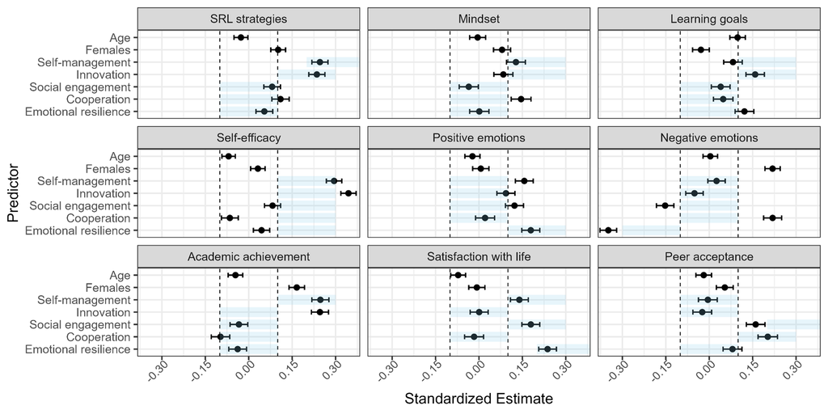

Figure 9: L’effetto delle SEB skill su aspetti di approccio allo studio, successo scolastico e benessere soggettivo e relazionale

È importante notare come tale impatto rimanga significativo indipendentemente da altre variabili individuali, come abilità cognitive, tratti di personalità o status socioeconomico. In altre parole, nonostante l’alta correlazione tra tratti e skill insita nelle misure e teorie di soft skill, quando opportunamente misurate (quindi non utilizzando esattamente gli stessi questionari usati per i tratti), le skill predicono gli outcome al netto di quanto già facciano i tratti di personalità<sup>29,30</sup>. Cosa vuol dire questo?

Immagina di voler prevedere il peso di una persona usando due variabili: altezza e età.

1. Senza controllare per altezza: Supponiamo che le persone più anziane tendano a pesare di più. Se consideriamo solo l’età, vediamo che sembra avere un potere predittivo sul peso.
2. Controllando per altezza: Introduciamo l’altezza. Una parte del legame tra età e peso potrebbe essere dovuta al fatto che le persone più alte tendono a pesare di più e gli adulti (che sono più anziani) sono generalmente più alti rispetto ai bambini.

Il potere predittivo di una variabile (età) al netto di un’altra (altezza) è ciò che rimane una volta tolto l’effetto dell’altra (altezza). Questo ci aiuta a capire se l’età influisce sul peso *indipendentemente* o *al netto* dall’altezza. Quindi le *skill* sembrano predire gli outcome *al netto dei tratti* corrispondenti.

# References

1.

Duckworth, A. L. & Yeager, D. S. [Measurement Matters: Assessing Personal Qualities Other Than Cognitive Ability for Educational Purposes](https://doi.org/10.3102/0013189X15584327). *Educational Researcher* **44**, 237–251 (2015).

2.

Heckman, J. J. & Kautz, T. [Hard evidence on soft skills](https://doi.org/10.1016/j.labeco.2012.05.014). *Labour Economics* **19**, 451–464 (2012).

3.

Soto, C. J., Napolitano, C. M. & Roberts, B. W. [Taking Skills Seriously: Toward an Integrative Model and Agenda for Social, Emotional, and Behavioral Skills](https://doi.org/10.1177/0963721420978613). *Current Directions in Psychological Science* **30**, 26–33 (2021).

4.

Abrahams, L. *et al.* [Social-emotional skill assessment in children and adolescents: Advances and challenges in personality, clinical, and educational contexts](https://doi.org/10.1037/pas0000591). *Psychological Assessment* **31**, 460–473 (2019).

5.

Park, D., Tsukayama, E., Goodwin, G. P., Patrick, S. & Duckworth, A. L. [A tripartite taxonomy of character: Evidence for intrapersonal, interpersonal, and intellectual competencies in children](https://doi.org/10.1016/j.cedpsych.2016.08.001). *Contemporary Educational Psychology* **48**, 16–27 (2017).

6.

Peterson, C. & Seligman, M. E. P. *Character Strengths and Virtues: A Handbook and Classification*. (American Psychological Association, 2004).

7.

Stewart, C., Wall, A. & Marciniec, S. [Mixed Signals: Do College Graduates Have the Soft Skills That Employers Want? - ProQuest](https://www.proquest.com/scholarly-journals/mixed-signals-do-college-graduates-have-soft/docview/1838503198/se-2). *Competition Forum* **14**, 276–281 (2016).

8.

Feraco, T. & Meneghetti, C. [Social, Emotional, and Behavioral Skills: Age and Gender Differences at 12 to 19 Years Old](https://doi.org/10.3390/jintelligence11060118). *Journal of Intelligence* **11**, 118 (2023).

9.

Feraco, T., Resnati, D., Fregonese, D., Spoto, A. & Meneghetti, C. [Soft Skills and Extracurricular Activities Sustain Motivation and Self-Regulated Learning at School](https://doi.org/10.1080/00220973.2021.1873090). *The Journal of Experimental Education* **90**, 550–569 (2022).

10.

Robles, M. M. [Executive perceptions of the top 10 soft skills needed in today’s workplace](https://doi.org/10.1177/1080569912460400). *Business Communication Quarterly* **75**, 453–465 (2012).

11.

Pellegrino, J. W. & Hilton, M. L. *Education for Life and Work: Developing Transferable Knowledge and Skills in the 21st Century*. (National Academies Press, 2012).

12.

Feraco, T., ResnatI, D., Fregonese, D., Spoto, A. & Meneghetti, C. [An integrated model of school students’ academic achievement and life satisfaction. Linking soft skills, extracurricular activities, self-regulated learning, motivation, and emotions](https://doi.org/10.1007/s10212-022-00601-4). *European Journal of Psychology of Education* **38**, 109–130 (2023).

13.

Roberts, B. W. & Yoon, H. J. [Personality Psychology](https://doi.org/10.1146/annurev-psych-020821-114927). *Annual Review of Psychology* **73**, 489–516 (2022).

14.

Ringwald, W. R. *et al.* More Skill than Trait, or More Trait than Skill? Relations of (Mis)matches between Personality Traits and Social, Emotional, Behavioral Skills with Adolescent Outcomes. (2023) doi:10.31234/osf.io/d2z5b.

15.

Chamorro‐Premuzic, T., Arteche, A., Bremner, A. J., Greven, C. & Furnham, A. [Soft skills in higher education: Importance and improvement ratings as a function of individual differences and academic performance](https://doi.org/10.1080/01443410903560278). *Educational Psychology* **30**, 221–241 (2010).

16.

Soto, C. J., Napolitano, C. M., Sewell, M. N., Yoon, H. J. & Roberts, B. W. An integrative framework for conceptualizing and assessing social, emotional, and behavioral skills: The BESSI. *Journal of Personality and Social Psychology* (2022) doi:10.1037/pspp0000401.

17.

Lechner, C. M. *et al.* [The Behavioral, Emotional, and Social Skills Inventory (BESSI): Psychometric Properties of a German-Language Adaptation, Temporal Stabilities of the Skills, and Associations with Personality and Intelligence](https://doi.org/10.3390/jintelligence10030063). *Journal of Intelligence* **10**, 63 (2022).

18.

Postigo, Á. *et al.* The Behavioral, Emotional, and Social Skills Inventory: A Spanish Adaptation and Further Validation in Adult Population. *Assessment* 10731911231225197 (2024) doi:10.1177/10731911231225197.

19.

Feraco, T. *et al.* [The Italian Behavioral, Emotional, and Social Skills Inventory (BESSI-I)](https://doi.org/10.1080/00223891.2024.2335912). *Journal of Personality Assessment* **0**, 1–15 (2024).

20.

OECD. [Skills for Social Progress: The Power of Social and Emotional Skills](https://www.oecd.org/education/skills-for-social-progress-9789264226159-en.htm). (2015).

21.

Napolitano, C. M., Sewell, M. N., Yoon, H. J., Soto, C. J. & Roberts, Brent. W. [Social, Emotional, and Behavioral Skills: An Integrative Model of the Skills Associated With Success During Adolescence and Across the Life Span](https://www.frontiersin.org/article/10.3389/feduc.2021.679561). *Frontiers in Education* **6**, (2021).

22.

Lechner, C. M. & Urban, J. [Inequalities in adolescents’ social, emotional, and behavioral skills: Differences across social categories and their intersections](https://doi.org/10.1016/j.lindif.2024.102605). *Learning and Individual Differences* **118**, 102605 (2025).

23.

Hudson, N. W. & Fraley, R. C. [Do People’s Desires to Change Their Personality Traits Vary With Age? An Examination of Trait Change Goals Across Adulthood](https://doi.org/10.1177/1948550616657598). *Social Psychological and Personality Science* **7**, 847–856 (2016).

24.

Thielmann, I. & Vries, R. E. de. [Who wants to change and how? On the trait-specificity of personality change goals](https://doi.org/10.1037/pspp0000304). *Journal of Personality and Social Psychology* **121**, 1112–1139 (2021).

25.

Dweck, C. S. [Can Personality Be Changed? The Role of Beliefs in Personality and Change](https://doi.org/10.1111/j.1467-8721.2008.00612.x). *Current Directions in Psychological Science* **17**, 391–394 (2008).

26.

Chen, L., Zhang, B. & Li, J. [Social, Emotional, and Behavioral (SEB) Skills in the Workplace](https://doi.org/10.1525/collabra.120531). *Collabra: Psychology* **10**, 120531 (2024).

27.

Pellegrino, G. *et al.* The Skilled Student: Linking Social, Emotional, and Behavioral Skills to Engagement and Student Outcomes in Secondary School Students. (2024) doi:10.31234/osf.io/rhmgk.

28.

Yoon, H. J. *et al.* [Examining SEB skills’ incremental validity over personality traits in predicting academic achievement](https://doi.org/10.1371/journal.pone.0296484). *PLOS ONE* **19**, e0296484 (2024).

29.

Roemer, L., Rammstedt, B. & Lechner, C. M. [Do social engagement skills exist and matter beyond personality facet traits and vocational interests? A generalization study across six countries](https://doi.org/10.1016/j.lindif.2024.102522). *Learning and Individual Differences* **115**, 102522 (2024).

30.

Soto, C. J., Napolitano, C. M., Sewell, M. N., Yoon, H. J. & Roberts, B. W. Going Beyond Traits: Social, Emotional, and Behavioral Skills Matter for Adolescents’ Success. *Social Psychological and Personality Science* 19485506221127483 (2022) doi:10.1177/19485506221127483.

31.

Sini, B., Cavaglià, R. & Tinti, C. *DSA: percorsi inclusivi in università. Inquadramento teorico e implicazioni pratiche*. (Franco Angeli, 2024).

GitHub repository associated to the present course website: https://github.com/tferaco93/Personality-and-individual-differences

Many thanks to Nicole Casali and Chiara Meneghetti for writing with me a different chapter on SEB skills<sup>31</sup>.